# Untitled-Copy1

```python
import pandas as pd

import numpy as np
from sklearn.metrics import mean_squared_error
import matplotlib.pyplot as plt
import seaborn as sns

from sklearn.metrics import mean_absolute_error

from sklearn.model_selection import train_test_split
from sklearn.ensemble import RandomForestRegressor
from sklearn.model_selection import GridSearchCV
from sklearn.metrics import accuracy_score,confusion_matrix,f1_score,precision_score,recall_score
```

```python
train=pd.read_csv('train_V2.csv')
```

```python
train.head()
```

|  | Id | groupId | matchId | assists | boosts | damageDealt | DBNOs | headshotKills | heals | killPlace | ... | revives | rideDistance | roadKills | swimDistance | teamKills | vehicleDestroys | walkDistance | weaponsAcquired | winPoints | winPlacePerc |
| --- | --- | --- | --- | --- | --- | --- | --- | --- | --- | --- | --- | --- | --- | --- | --- | --- | --- | --- | --- | --- | --- |
| 0 | 7f96b2f878858a | 4d4b580de459be | a10357fd1a4a91 | 0 | 0 | 0.00 | 0 | 0 | 0 | 60 | ... | 0 | 0.0000 | 0 | 0.00 | 0 | 0 | 244.80 | 1 | 1466 | 0.4444 |
| 1 | eef90569b9d03c | 684d5656442f9e | aeb375fc57110c | 0 | 0 | 91.47 | 0 | 0 | 0 | 57 | ... | 0 | 0.0045 | 0 | 11.04 | 0 | 0 | 1434.00 | 5 | 0 | 0.6400 |
| 2 | 1eaf90ac73de72 | 6a4a42c3245a74 | 110163d8bb94ae | 1 | 0 | 68.00 | 0 | 0 | 0 | 47 | ... | 0 | 0.0000 | 0 | 0.00 | 0 | 0 | 161.80 | 2 | 0 | 0.7755 |
| 3 | 4616d365dd2853 | a930a9c79cd721 | f1f1f4ef412d7e | 0 | 0 | 32.90 | 0 | 0 | 0 | 75 | ... | 0 | 0.0000 | 0 | 0.00 | 0 | 0 | 202.70 | 3 | 0 | 0.1667 |
| 4 | 315c96c26c9aac | de04010b3458dd | 6dc8ff871e21e6 | 0 | 0 | 100.00 | 0 | 0 | 0 | 45 | ... | 0 | 0.0000 | 0 | 0.00 | 0 | 0 | 49.75 | 2 | 0 | 0.1875 |

5 rows × 29 columns

```python
# Checking row with winPlacePerc with NULL values
train[train['winPlacePerc'].isnull()]
```

|  | Id | groupId | matchId | assists | boosts | damageDealt | DBNOs | headshotKills | heals | killPlace | ... | revives | rideDistance | roadKills | swimDistance | teamKills | vehicleDestroys | walkDistance | weaponsAcquired | winPoints | winPlacePerc |
| --- | --- | --- | --- | --- | --- | --- | --- | --- | --- | --- | --- | --- | --- | --- | --- | --- | --- | --- | --- | --- | --- |
| 2744604 | f70c74418bb064 | 12dfbede33f92b | 224a123c53e008 | 0 | 0 | 0.0 | 0 | 0 | 0 | 1 | ... | 0 | 0.0 | 0 | 0.0 | 0 | 0 | 0.0 | 0 | 0 | NaN |

1 rows × 29 columns

```python
#Deleting the row
train.drop(2744604, inplace=True)
```

```python
train[train['winPlacePerc'].isnull()]
```

|  | Id | groupId | matchId | assists | boosts | damageDealt | DBNOs | headshotKills | heals | killPlace | ... | revives | rideDistance | roadKills | swimDistance | teamKills | vehicleDestroys | walkDistance | weaponsAcquired | winPoints | winPlacePerc |
| --- | --- | --- | --- | --- | --- | --- | --- | --- | --- | --- | --- | --- | --- | --- | --- | --- | --- | --- | --- | --- | --- |

0 rows × 29 columns

```python
# Create feature totalDistance
train['totalDistance'] = train['rideDistance'] + train['walkDistance'] + train['swimDistance']
# Create feature killsWithoutMoving
train['killsWithoutMoving'] = ((train['kills'] > 0) & (train['totalDistance'] == 0))
```

## The killer Players

```python
print("The average person kills {:.4f} players, 99% of people have {} kills or less, while the most kills ever \
recorded is {}.".format(train['kills'].mean(),train['kills'].quantile(0.99), train['kills'].max()))
```

[output not shown]

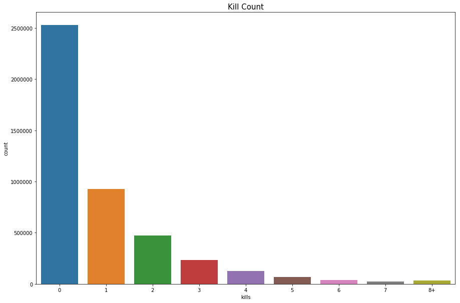

```python
data = train.copy()
data.loc[data['kills'] > data['kills'].quantile(0.99)] = '8+'
plt.figure(figsize=(15,10))
sns.countplot(data['kills'].astype('str').sort_values())
plt.title("Kill Count",fontsize=15)
plt.show()
```

### Most players are not able to kill a single person, so now we will plot the damage done by players with 0 kills.

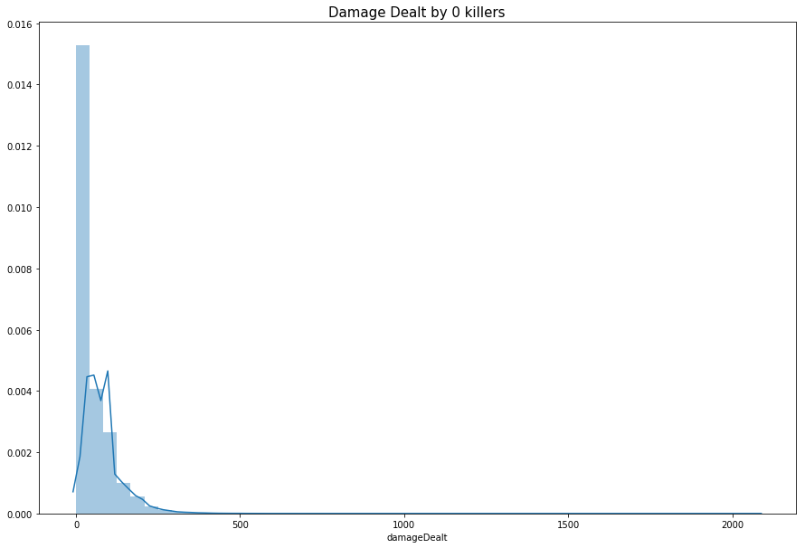

```python
data = train.copy()
data = data[data['kills']==0]
plt.figure(figsize=(15,10))
plt.title("Damage Dealt by 0 killers",fontsize=15)
sns.distplot(data['damageDealt'])
plt.show()
```

### Most of the player don't do any damage, but some have. So, we are checking who have won without killing anyone and without doing any damage.

```python
print("{} players ({:.4f}%) have won without a single kill!".format(len(data[data['winPlacePerc']==1]), 100*len(data[data['winPlacePerc']==1])/len(train)))

data1 = train[train['damageDealt'] == 0].copy()
print("{} players ({:.4f}%) have won without dealing damage!".format(len(data1[data1['winPlacePerc']==1]), 100*len(data1[data1['winPlacePerc']==1])/len(train)))
```

```
16661 players (0.3748%) have won without a single kill!
4769 players (0.1073%) have won without dealing damage!
```

### Plotting win placement percentage vs kills

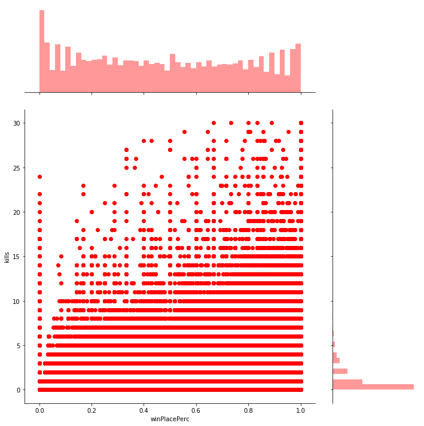

```python
sns.jointplot(x="winPlacePerc", y="kills",height=10, data=train, ratio=3, color="r")
plt.show()
```

### killing has a correlation with winning. So, we are grouping players based on kills (0 kills, 1-2 kills, 3-5 kills, 6-10 kills and 10+ kills).

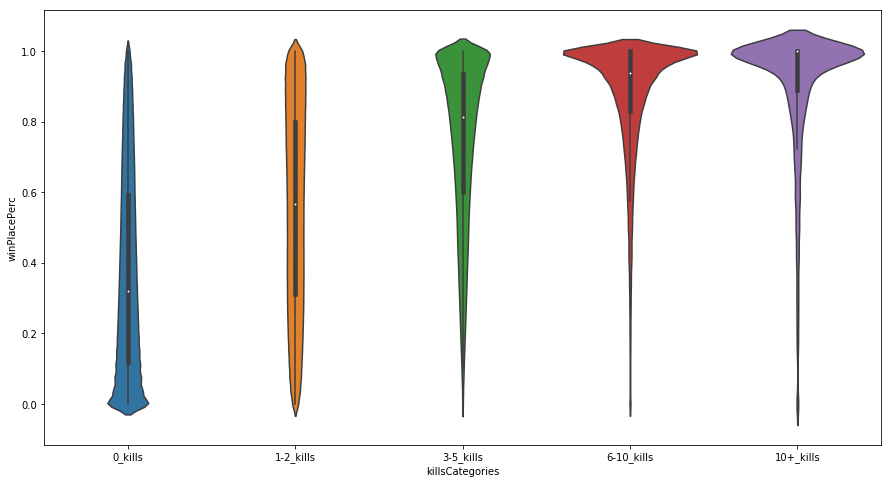

```python
kills = train.copy()
kills['killsCategories'] = pd.cut(kills['kills'], [-1, 0, 2, 5, 10, 60], labels=['0_kills','1-2_kills', '3-5_kills', '6-10_kills', '10+_kills'])
plt.figure(figsize=(15,8))
sns.violinplot(x="killsCategories", y="winPlacePerc", data=kills)
plt.show()
```

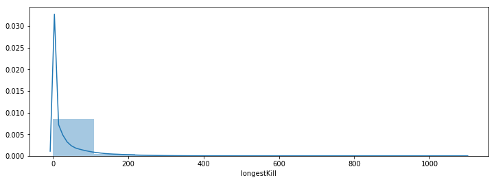

```python
# Plot the distribution of longestKill
plt.figure(figsize=(12,4))
sns.distplot(train['longestKill'], bins=10)
plt.show()
```

```python
# Check out players who made kills with a distance of more than 1 km
display(train[train['longestKill'] >= 1000].shape)
train[train['longestKill'] >= 1000].head(10)
```

```
(20, 31)
```

|  | Id | groupId | matchId | assists | boosts | damageDealt | DBNOs | headshotKills | heals | killPlace | ... | roadKills | swimDistance | teamKills | vehicleDestroys | walkDistance | weaponsAcquired | winPoints | winPlacePerc | totalDistance | killsWithoutMoving |
| --- | --- | --- | --- | --- | --- | --- | --- | --- | --- | --- | --- | --- | --- | --- | --- | --- | --- | --- | --- | --- | --- |
| 202281 | 88e2af7d78af5a | 34ddeede52c042 | 4346bc63bc67fa | 0 | 3 | 783.9 | 5 | 1 | 1 | 5 | ... | 0 | 0.0 | 0 | 1 | 3052.00 | 9 | 0 | 0.9231 | 3775.20 | False |
| 240005 | 41c2f5c0699807 | 9faecf87ab4275 | 634edab75860b3 | 5 | 0 | 1284.0 | 8 | 5 | 7 | 18 | ... | 0 | 0.0 | 0 | 0 | 48.87 | 38 | 1500 | 0.5385 | 48.87 | False |
| 324313 | ef390c152bcc3d | 30fd444be3bbc1 | 4f7f8d6cf558b4 | 2 | 0 | 1028.0 | 0 | 0 | 0 | 9 | ... | 0 | 0.0 | 0 | 0 | 1264.00 | 26 | 0 | 1.0000 | 2981.00 | False |
| 656553 | 9948b058562163 | c8cb8491112bf6 | 0104eeb664494d | 6 | 0 | 1410.0 | 17 | 5 | 0 | 3 | ... | 0 | 0.0 | 0 | 0 | 29.21 | 30 | 1500 | 0.6000 | 29.21 | False |
| 803632 | 4e7e6c74e3c57d | 94698690918933 | da91b0c3d875f8 | 0 | 0 | 196.8 | 0 | 0 | 0 | 51 | ... | 0 | 0.0 | 0 | 0 | 1074.00 | 22 | 0 | 0.0000 | 3159.00 | False |
| 895411 | 1f5ba6e0cfb968 | 512ea24b831be3 | 5fb0d8b1fc16cf | 4 | 0 | 1012.0 | 11 | 5 | 0 | 5 | ... | 0 | 0.0 | 0 | 0 | 569.50 | 18 | 0 | 0.9091 | 569.50 | False |
| 1172437 | 303a93cfa1f46c | 8795d39fd0df86 | 9c8962b58bb3e3 | 2 | 1 | 329.3 | 0 | 0 | 2 | 45 | ... | 0 | 0.0 | 0 | 0 | 832.50 | 9 | 1500 | 0.2857 | 832.50 | False |
| 1209416 | 528659ff1c1aec | 7d1ba83423551d | ea9386587d5888 | 0 | 6 | 1640.0 | 0 | 7 | 0 | 1 | ... | 0 | 0.0 | 0 | 0 | 2848.00 | 4 | 1500 | 0.9412 | 2848.00 | False |
| 1642712 | 91966848e08e2f | 0ee4fbd27657c9 | 17dea22cefe62a | 3 | 2 | 2103.0 | 0 | 4 | 11 | 11 | ... | 0 | 0.0 | 0 | 0 | 235.30 | 41 | 0 | 0.5000 | 235.30 | False |
| 2015559 | 5ff0c1a9fab2ba | 2d8119b1544f87 | 904cecf36217df | 3 | 3 | 1302.0 | 0 | 6 | 5 | 15 | ... | 0 | 0.0 | 0 | 0 | 133.20 | 43 | 0 | 0.6000 | 133.20 | False |

10 rows × 31 columns

```python
# Remove outliers
train.drop(train[train['longestKill'] >= 1000].index, inplace=True)
```

## The Runner Players

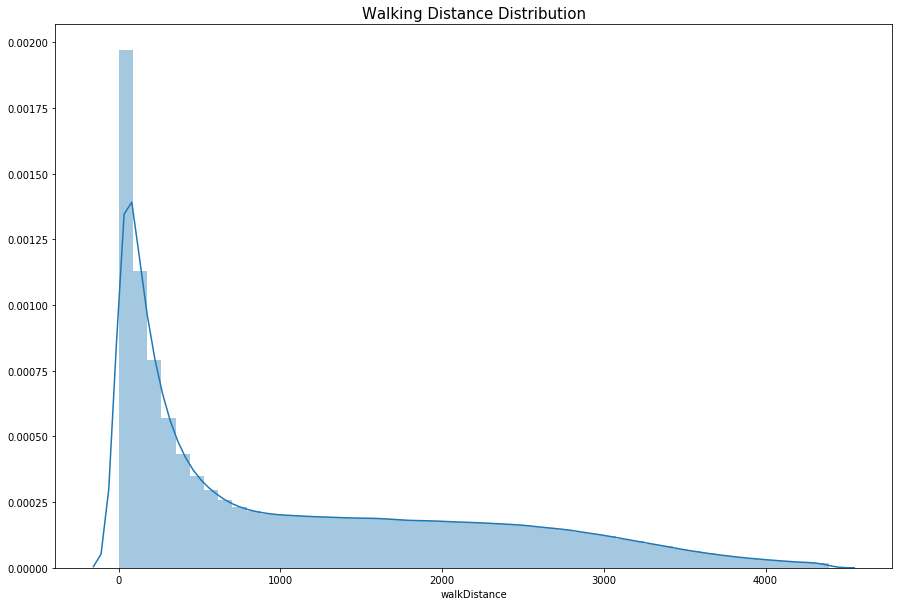

```python
data = train.copy()
data = data[data['walkDistance'] < train['walkDistance'].quantile(0.99)]
plt.figure(figsize=(15,10))
plt.title("Walking Distance Distribution",fontsize=15)
sns.distplot(data['walkDistance'])
plt.show()
```

```python
print("{} players ({:.4f}%) walked 0 meters. This means that they die before even taking a step.".format(len(data[data['walkDistance'] == 0]), 100*len(data1[data1['walkDistance']==0])/len(train)))
```

[output not shown]

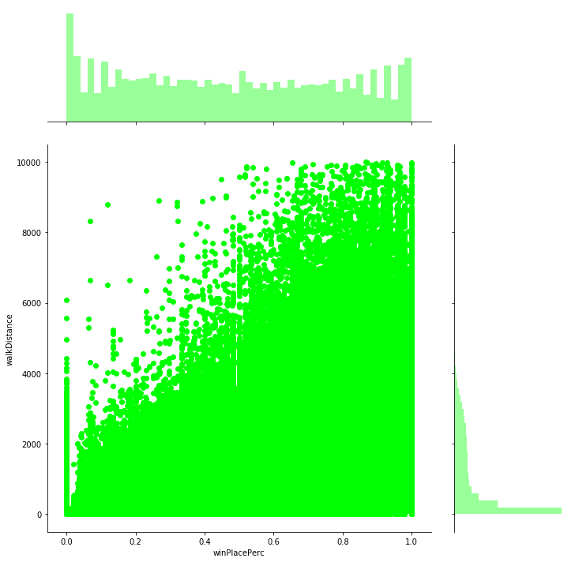

```python
sns.jointplot(x="winPlacePerc", y="walkDistance",  data=train, height=10, ratio=3, color="lime")
plt.show()
```

### Walking has a high correlation with Win Placement Percentage**.

```python
# Check players who kills without moving
display(train[train['killsWithoutMoving'] == True].shape)
train[train['killsWithoutMoving'] == True].head(10)
```

```
(1535, 31)
```

|  | Id | groupId | matchId | assists | boosts | damageDealt | DBNOs | headshotKills | heals | killPlace | ... | roadKills | swimDistance | teamKills | vehicleDestroys | walkDistance | weaponsAcquired | winPoints | winPlacePerc | totalDistance | killsWithoutMoving |
| --- | --- | --- | --- | --- | --- | --- | --- | --- | --- | --- | --- | --- | --- | --- | --- | --- | --- | --- | --- | --- | --- |
| 1824 | b538d514ef2476 | 0eb2ce2f43f9d6 | 35e7d750e442e2 | 0 | 0 | 593.00 | 0 | 0 | 3 | 18 | ... | 0 | 0.0 | 0 | 0 | 0.0 | 8 | 0 | 0.8571 | 0.0 | True |
| 6673 | 6d3a61da07b7cb | 2d8119b1544f87 | 904cecf36217df | 2 | 0 | 346.60 | 0 | 0 | 6 | 33 | ... | 0 | 0.0 | 0 | 0 | 0.0 | 22 | 0 | 0.6000 | 0.0 | True |
| 11892 | 550398a8f33db7 | c3fd0e2abab0af | db6f6d1f0d4904 | 2 | 0 | 1750.00 | 0 | 4 | 5 | 3 | ... | 0 | 0.0 | 0 | 0 | 0.0 | 13 | 0 | 0.8947 | 0.0 | True |
| 14631 | 58d690ee461e9d | ea5b6630b33d67 | dbf34301df5e53 | 0 | 0 | 157.80 | 0 | 0 | 0 | 69 | ... | 0 | 0.0 | 0 | 0 | 0.0 | 7 | 1500 | 0.0000 | 0.0 | True |
| 15591 | 49b61fc963d632 | 0f5c5f19d9cc21 | 904cecf36217df | 0 | 0 | 100.00 | 0 | 1 | 0 | 37 | ... | 0 | 0.0 | 0 | 0 | 0.0 | 10 | 0 | 0.3000 | 0.0 | True |
| 20881 | 40871bf43ddac7 | 2cea046b7d1dce | 0600f86f11c6e4 | 0 | 0 | 506.10 | 4 | 1 | 3 | 7 | ... | 0 | 0.0 | 0 | 0 | 0.0 | 8 | 0 | 0.8000 | 0.0 | True |
| 23298 | b950836d0427da | 1f735b1e00d549 | ad860f4e162bbc | 1 | 0 | 1124.00 | 0 | 4 | 1 | 7 | ... | 0 | 0.0 | 0 | 0 | 0.0 | 8 | 0 | 0.6000 | 0.0 | True |
| 24640 | aeced11d46de19 | d4009ffa95bb4f | 73f3ed869c9171 | 2 | 0 | 529.90 | 0 | 2 | 11 | 12 | ... | 0 | 0.0 | 0 | 0 | 0.0 | 8 | 0 | 0.8571 | 0.0 | True |
| 25659 | 6626c4d47cffa0 | ee3fe5c0d917c3 | 341341834b7941 | 0 | 1 | 128.90 | 0 | 1 | 6 | 53 | ... | 0 | 0.0 | 0 | 0 | 0.0 | 12 | 1500 | 0.2857 | 0.0 | True |
| 30079 | 869331b90bfa3f | 869ea3ad036e53 | fa373e28ff5062 | 0 | 0 | 85.56 | 0 | 0 | 0 | 46 | ... | 0 | 0.0 | 0 | 0 | 0.0 | 4 | 0 | 0.8571 | 0.0 | True |

10 rows × 31 columns

```python
# Remove outliers
train.drop(train[train['killsWithoutMoving'] == True].index, inplace=True)
```

```python
# Players who got more than 10 roadKills
train[train['roadKills'] > 10]
```

|  | Id | groupId | matchId | assists | boosts | damageDealt | DBNOs | headshotKills | heals | killPlace | ... | roadKills | swimDistance | teamKills | vehicleDestroys | walkDistance | weaponsAcquired | winPoints | winPlacePerc | totalDistance | killsWithoutMoving |
| --- | --- | --- | --- | --- | --- | --- | --- | --- | --- | --- | --- | --- | --- | --- | --- | --- | --- | --- | --- | --- | --- |
| 2733926 | c3e444f7d1289f | 489dd6d1f2b3bb | 4797482205aaa4 | 0 | 0 | 1246.0 | 0 | 0 | 0 | 1 | ... | 14 | 5.297 | 0 | 0 | 1277.0 | 0 | 1371 | 0.4286 | 1282.302 | False |
| 2767999 | 34193085975338 | bd7d50fa305700 | a22354d036b3d6 | 0 | 0 | 1102.0 | 0 | 0 | 0 | 1 | ... | 11 | 0.000 | 0 | 0 | 816.6 | 5 | 1533 | 0.4713 | 4934.600 | False |
| 2890740 | a3438934e3e535 | 1081c315a80d14 | fe744430ac0070 | 0 | 8 | 2074.0 | 0 | 1 | 11 | 1 | ... | 18 | 0.000 | 0 | 0 | 3150.0 | 4 | 1568 | 1.0000 | 5876.000 | False |
| 3524413 | 9d9d044f81de72 | 8be97e1ba792e3 | 859e2c2db5b125 | 0 | 3 | 1866.0 | 0 | 5 | 7 | 1 | ... | 11 | 0.000 | 0 | 0 | 1041.0 | 10 | 1606 | 0.9398 | 7853.000 | False |

4 rows × 31 columns

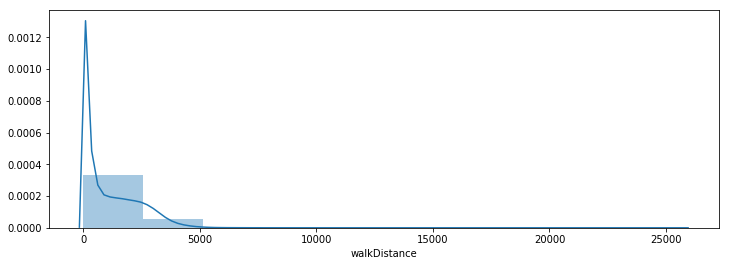

```python
# Plot the distribution of walkDistance
plt.figure(figsize=(12,4))
sns.distplot(train['walkDistance'], bins=10)
plt.show()
```

```python
# walkDistance anomalies
display(train[train['walkDistance'] >= 10000].shape)
train[train['walkDistance'] >= 10000].head(10)
```

```
(219, 31)
```

|  | Id | groupId | matchId | assists | boosts | damageDealt | DBNOs | headshotKills | heals | killPlace | ... | roadKills | swimDistance | teamKills | vehicleDestroys | walkDistance | weaponsAcquired | winPoints | winPlacePerc | totalDistance | killsWithoutMoving |
| --- | --- | --- | --- | --- | --- | --- | --- | --- | --- | --- | --- | --- | --- | --- | --- | --- | --- | --- | --- | --- | --- |
| 23026 | 8a6562381dd83f | 23e638cd6eaf77 | b0a804a610e9b0 | 0 | 1 | 0.00 | 0 | 0 | 0 | 44 | ... | 0 | 9.882 | 0 | 0 | 13530.0 | 7 | 0 | 0.8163 | 13540.3032 | False |
| 34344 | 5a591ecc957393 | 6717370b51c247 | a15d93e7165b05 | 0 | 3 | 23.22 | 0 | 0 | 1 | 34 | ... | 0 | 40.870 | 0 | 0 | 10030.0 | 7 | 1533 | 0.9474 | 10070.9073 | False |
| 49312 | 582685f487f0b4 | 338112cd12f1e7 | d0afbf5c3a6dc9 | 0 | 4 | 117.20 | 1 | 0 | 1 | 24 | ... | 0 | 36.750 | 0 | 0 | 12410.0 | 3 | 0 | 0.9130 | 12446.7588 | False |
| 68590 | 8c0d9dd0b4463c | c963553dc937e9 | 926681ea721a47 | 0 | 1 | 32.34 | 0 | 0 | 1 | 46 | ... | 0 | 45.820 | 0 | 0 | 11590.0 | 3 | 1563 | 0.8333 | 12483.6200 | False |
| 94400 | d441bebd01db61 | 7e179b3366adb8 | 923b57b8b834cc | 1 | 1 | 73.08 | 0 | 0 | 3 | 27 | ... | 0 | 45.630 | 0 | 0 | 10440.0 | 6 | 1488 | 0.8194 | 11490.6300 | False |
| 125103 | db5a0cdc969dcb | 50cc466757950e | c306a9745c4c1d | 0 | 4 | 37.73 | 0 | 0 | 7 | 47 | ... | 0 | 38.760 | 0 | 0 | 12790.0 | 5 | 1500 | 0.7340 | 12828.7978 | False |
| 136421 | 955e60b09a96b1 | 30df08fe22a901 | 8669d01725f135 | 0 | 1 | 0.00 | 0 | 0 | 1 | 46 | ... | 0 | 30.810 | 0 | 0 | 10370.0 | 3 | 0 | 0.6957 | 12223.8100 | False |
| 136476 | 0d75d05b5c988c | 3da040ce77cd0b | 65bc5211a569dd | 0 | 3 | 0.00 | 0 | 0 | 0 | 41 | ... | 0 | 197.200 | 0 | 0 | 10140.0 | 5 | 1772 | 0.9333 | 14918.2000 | False |
| 154080 | 7e8a71d23381cd | e2c9f4f92840b2 | a721de1aa05408 | 0 | 3 | 0.00 | 0 | 0 | 13 | 46 | ... | 0 | 16.700 | 0 | 0 | 10220.0 | 4 | 0 | 0.8602 | 12636.7000 | False |
| 154128 | 32fdde4c716787 | 390ae9a51c11b8 | 82610ed1b4d033 | 0 | 4 | 52.16 | 0 | 0 | 7 | 25 | ... | 0 | 29.830 | 0 | 0 | 10860.0 | 6 | 0 | 0.8936 | 10889.8614 | False |

10 rows × 31 columns

```python
# Remove outliers
train.drop(train[train['walkDistance'] >= 10000].index, inplace=True)
```

## The Driver Players

```python
print("The average person drives for {:.1f}m, 99% of people have drived {}m or less, while the maximum distance covered by a single person was {}m.".format(train['rideDistance'].mean(), train['rideDistance'].quantile(0.99), train['rideDistance'].max()))
```

[output not shown]

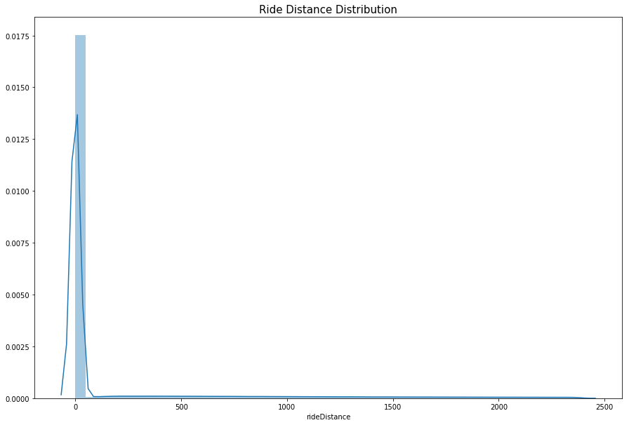

```python
data = train.copy()
data = data[data['rideDistance'] < train['rideDistance'].quantile(0.9)]
plt.figure(figsize=(15,10))
plt.title("Ride Distance Distribution",fontsize=15)
sns.distplot(data['rideDistance'])
plt.show()
```

```python
print("{} players ({:.4f}%) drived for 0 meters.".format(len(data[data['rideDistance'] == 0]), 100*len(data1[data1['rideDistance']==0])/len(train)))
```

[output not shown]

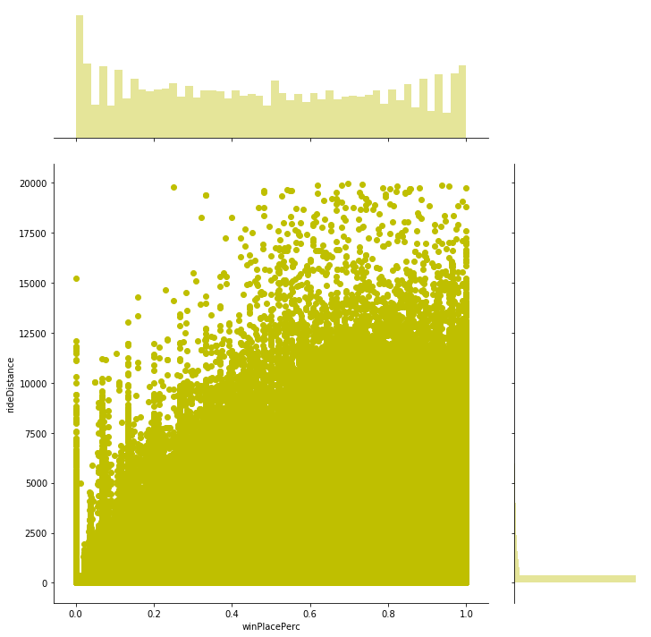

```python
sns.jointplot(x="winPlacePerc", y="rideDistance", data=train, height=10, ratio=3, color="y")
plt.show()
```

### There is a small correlation between Ride Distance and Win Placement Percentage.

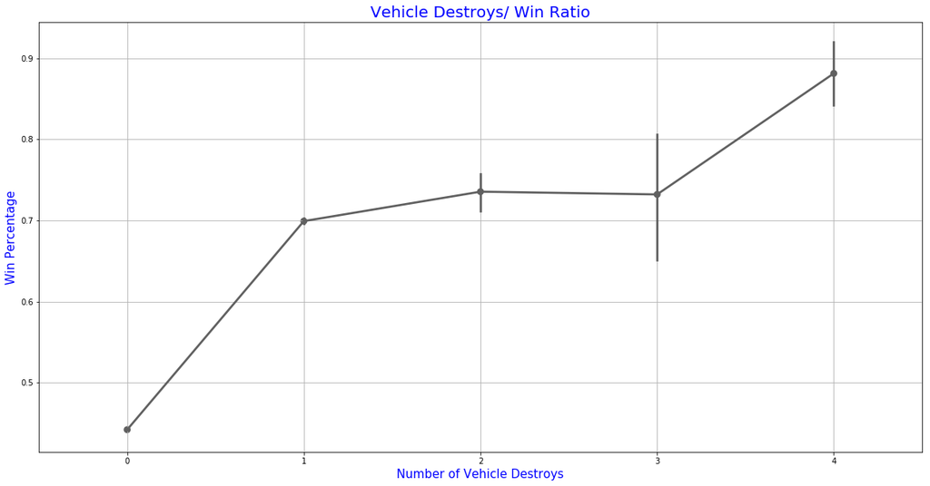

```python
f,ax1 = plt.subplots(figsize =(20,10))
sns.pointplot(x='vehicleDestroys',y='winPlacePerc',data=data,color='#606060',alpha=0.8)
plt.xlabel('Number of Vehicle Destroys',fontsize = 15,color='blue')
plt.ylabel('Win Percentage',fontsize = 15,color='blue')
plt.title('Vehicle Destroys/ Win Ratio',fontsize = 20,color='blue')
plt.grid()
plt.show()
```

### The winning percentage increases with increase in number of vehicles destroyed

```python
# Drop roadKill outliers
train.drop(train[train['roadKills'] > 10].index, inplace=True)
```

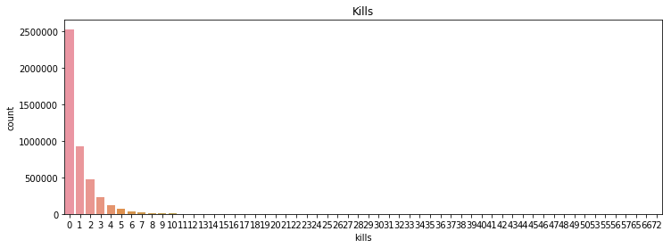

```python
# Plot the distribution of kills
plt.figure(figsize=(12,4))
sns.countplot(data=train, x=train['kills']).set_title('Kills')
plt.show()
```

```python
# Players who got more than 30 kills
display(train[train['kills'] > 30].shape)
train[train['kills'] > 30].head(10)
```

```
(95, 31)
```

|  | Id | groupId | matchId | assists | boosts | damageDealt | DBNOs | headshotKills | heals | killPlace | ... | roadKills | swimDistance | teamKills | vehicleDestroys | walkDistance | weaponsAcquired | winPoints | winPlacePerc | totalDistance | killsWithoutMoving |
| --- | --- | --- | --- | --- | --- | --- | --- | --- | --- | --- | --- | --- | --- | --- | --- | --- | --- | --- | --- | --- | --- |
| 57978 | 9d8253e21ccbbd | ef7135ed856cd8 | 37f05e2a01015f | 9 | 0 | 3725.0 | 0 | 7 | 0 | 2 | ... | 0 | 0.0 | 0 | 0 | 48.82 | 48 | 1500 | 0.8571 | 48.82 | False |
| 87793 | 45f76442384931 | b3627758941d34 | 37f05e2a01015f | 8 | 0 | 3087.0 | 0 | 8 | 27 | 3 | ... | 0 | 0.0 | 0 | 0 | 780.70 | 45 | 1500 | 1.0000 | 780.70 | False |
| 156599 | 746aa7eabf7c86 | 5723e7d8250da3 | f900de1ec39fa5 | 21 | 0 | 5479.0 | 0 | 12 | 7 | 4 | ... | 0 | 0.0 | 0 | 0 | 23.71 | 61 | 0 | 0.7000 | 23.71 | False |
| 160254 | 15622257cb44e2 | 1a513eeecfe724 | db413c7c48292c | 1 | 0 | 4033.0 | 0 | 40 | 0 | 1 | ... | 0 | 0.0 | 1 | 0 | 718.30 | 16 | 1500 | 1.0000 | 718.30 | False |
| 180189 | 1355613d43e2d0 | f863cd38c61dbf | 39c442628f5df5 | 5 | 0 | 3171.0 | 0 | 6 | 15 | 1 | ... | 0 | 0.0 | 0 | 0 | 71.51 | 41 | 0 | 1.0000 | 71.51 | False |
| 334400 | 810f2379261545 | 7f3e493ee71534 | f900de1ec39fa5 | 20 | 0 | 6616.0 | 0 | 13 | 5 | 1 | ... | 0 | 0.0 | 0 | 0 | 1036.00 | 60 | 0 | 1.0000 | 1036.00 | False |
| 353128 | f3e9746e3ff151 | 4bc1f00f07b304 | a9e84c456cc859 | 2 | 0 | 3834.0 | 0 | 9 | 5 | 1 | ... | 0 | 0.0 | 0 | 0 | 124.20 | 42 | 0 | 1.0000 | 124.20 | False |
| 457829 | 265e23756baa0b | 9d94424171c2a1 | 664dee9ed8f646 | 3 | 0 | 2907.0 | 0 | 27 | 2 | 1 | ... | 0 | 0.0 | 1 | 0 | 382.40 | 15 | 0 | 1.0000 | 382.40 | False |
| 488335 | 31a0682922ef45 | 275a27a3ee4cc8 | 3037f74ef8a3a3 | 2 | 0 | 3055.0 | 0 | 9 | 0 | 1 | ... | 0 | 0.0 | 0 | 0 | 35.30 | 31 | 1500 | 1.0000 | 35.30 | False |
| 662650 | dd424a8b74bd49 | ac9dea6d62f2e6 | 8a728def0644be | 9 | 0 | 3454.0 | 38 | 9 | 4 | 1 | ... | 0 | 0.0 | 0 | 0 | 111.10 | 25 | 1500 | 0.2308 | 111.10 | False |

10 rows × 31 columns

```python
# Remove outliers
train.drop(train[train['kills'] > 30].index, inplace=True)
```

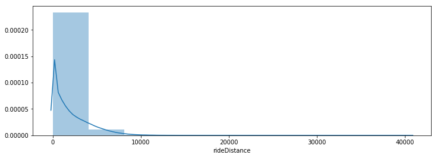

```python
# Plot the distribution of rideDistance
plt.figure(figsize=(12,4))
sns.distplot(train['rideDistance'], bins=10)
plt.show()
```

```python
# rideDistance anomalies
display(train[train['rideDistance'] >= 20000].shape)
train[train['rideDistance'] >= 20000].head(10)
```

```
(150, 31)
```

|  | Id | groupId | matchId | assists | boosts | damageDealt | DBNOs | headshotKills | heals | killPlace | ... | roadKills | swimDistance | teamKills | vehicleDestroys | walkDistance | weaponsAcquired | winPoints | winPlacePerc | totalDistance | killsWithoutMoving |
| --- | --- | --- | --- | --- | --- | --- | --- | --- | --- | --- | --- | --- | --- | --- | --- | --- | --- | --- | --- | --- | --- |
| 28588 | 6260f7c49dc16f | b24589f02eedd7 | 6ebea3b4f55b4a | 0 | 0 | 99.20 | 0 | 0 | 1 | 30 | ... | 0 | 0.0 | 0 | 0 | 376.60 | 6 | 0 | 0.6421 | 26306.60 | False |
| 63015 | adb7dae4d0c10a | 8ede98a241f30a | 8b36eac66378e4 | 0 | 0 | 0.00 | 0 | 0 | 0 | 55 | ... | 0 | 0.0 | 0 | 0 | 185.40 | 0 | 0 | 0.5376 | 22065.40 | False |
| 70507 | ca6fa339064d67 | f7bb2e30c3461f | 3bfd8d66edbeff | 0 | 0 | 100.00 | 0 | 0 | 0 | 26 | ... | 1 | 0.0 | 0 | 0 | 467.50 | 3 | 0 | 0.8878 | 28917.50 | False |
| 72763 | 198e5894e68ff4 | ccf47c82abb11f | d92bf8e696b61d | 0 | 0 | 0.00 | 0 | 0 | 0 | 46 | ... | 0 | 0.0 | 1 | 0 | 687.20 | 9 | 0 | 0.7917 | 21197.20 | False |
| 95276 | c3fabfce7589ae | 15529e25aa4a74 | d055504340e5f4 | 0 | 7 | 778.20 | 0 | 1 | 2 | 2 | ... | 2 | 0.0 | 0 | 0 | 923.20 | 6 | 0 | 0.9785 | 26733.20 | False |
| 140097 | 9944fbbea2b91e | 18b4d5f4bb1906 | d9d4a3e50cae75 | 1 | 0 | 12.55 | 0 | 0 | 0 | 53 | ... | 0 | 0.0 | 0 | 0 | 63.23 | 0 | 1514 | 0.5000 | 21293.23 | False |
| 297186 | 88904c200175b6 | 012a61a01e146e | 7a270c25e9b70c | 0 | 1 | 0.00 | 0 | 0 | 1 | 47 | ... | 0 | 0.0 | 0 | 0 | 297.30 | 3 | 0 | 0.7447 | 29267.30 | False |
| 371098 | f7071357f6b762 | f3ee20821f4627 | ac47c86bf385bf | 0 | 0 | 72.92 | 1 | 0 | 0 | 45 | ... | 0 | 0.0 | 0 | 0 | 242.10 | 4 | 0 | 0.6875 | 21942.10 | False |
| 403647 | c65da7b3fceef5 | 814d1b3736e276 | ff9f570b555d48 | 0 | 2 | 0.00 | 0 | 0 | 3 | 54 | ... | 0 | 0.0 | 0 | 0 | 598.20 | 1 | 0 | 0.6739 | 21198.20 | False |
| 426708 | 149e224a2330ae | 6d8cb80b3de8ff | f8b8e2643f60ee | 0 | 2 | 0.00 | 0 | 0 | 2 | 43 | ... | 0 | 0.0 | 0 | 0 | 402.10 | 3 | 1449 | 0.8171 | 32362.10 | False |

10 rows × 31 columns

```python
# Remove outliers
train.drop(train[train['rideDistance'] >= 20000].index, inplace=True)
```

## The swimmer Players

```python
print("The average person swims for {:.1f}m, 99% of people have swimmed {}m or less, while the maximum distance covered was {}m.".format(train['swimDistance'].mean(), train['swimDistance'].quantile(0.99), train['swimDistance'].max()))
```

[output not shown]

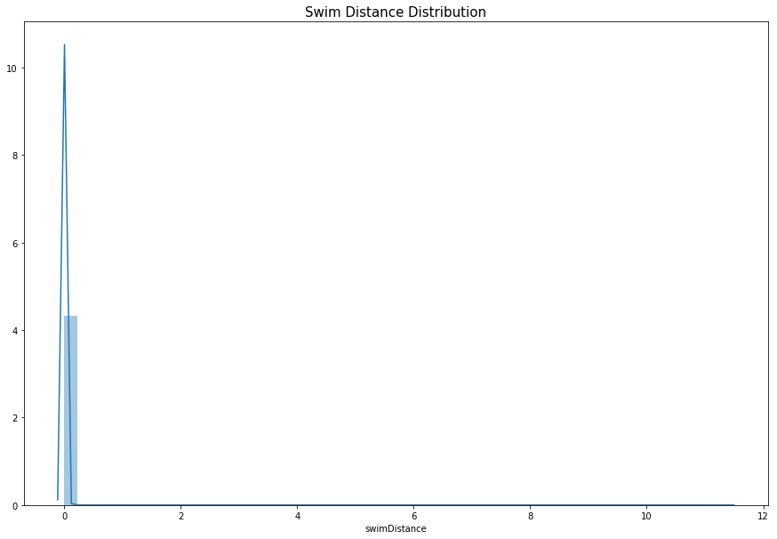

```python
data = train.copy()
data = data[data['swimDistance'] < train['swimDistance'].quantile(0.95)]
plt.figure(figsize=(15,10))
plt.title("Swim Distance Distribution",fontsize=15)
sns.distplot(data['swimDistance'])
plt.show()
```

### Almost no one swims. So, there is no use of proceeding with this.

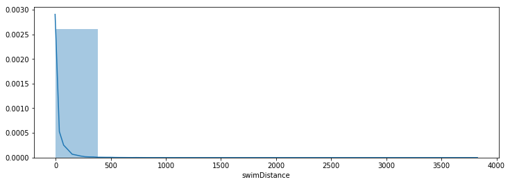

```python
# Plot the distribution of swimDistance
plt.figure(figsize=(12,4))
sns.distplot(train['swimDistance'], bins=10)
plt.show()
```

```python
# Players who swam more than 2 km
train[train['swimDistance'] >= 2000]
```

|  | Id | groupId | matchId | assists | boosts | damageDealt | DBNOs | headshotKills | heals | killPlace | ... | roadKills | swimDistance | teamKills | vehicleDestroys | walkDistance | weaponsAcquired | winPoints | winPlacePerc | totalDistance | killsWithoutMoving |
| --- | --- | --- | --- | --- | --- | --- | --- | --- | --- | --- | --- | --- | --- | --- | --- | --- | --- | --- | --- | --- | --- |
| 177973 | c2e9e5631f4e54 | 23213058f83abe | f01eb1073ef377 | 0 | 5 | 78.12 | 1 | 0 | 1 | 47 | ... | 0 | 2295.0 | 0 | 0 | 1002.000 | 4 | 1466 | 0.9592 | 3297.000 | False |
| 274258 | ba5e3dfb5a0fa0 | 383db055216ec2 | d6e13468e28ab4 | 0 | 4 | 53.32 | 0 | 0 | 16 | 39 | ... | 0 | 2148.0 | 0 | 0 | 2276.000 | 5 | 0 | 0.9600 | 10113.000 | False |
| 1005337 | d50c9d0e65fe2a | 4996575c11abcb | 668402592429f8 | 0 | 1 | 503.00 | 4 | 3 | 1 | 6 | ... | 0 | 2718.0 | 0 | 0 | 4691.000 | 5 | 1516 | 1.0000 | 10740.000 | False |
| 1195818 | f811de9de80b70 | d08ddf7beb6252 | 8a48703ab52ec8 | 0 | 7 | 352.30 | 3 | 1 | 6 | 4 | ... | 0 | 2668.0 | 0 | 0 | 415.100 | 10 | 1499 | 1.0000 | 3083.100 | False |
| 1227362 | a33e917875c80e | 5b72674b42712b | 5fb0d8b1fc16cf | 0 | 1 | 589.20 | 3 | 1 | 1 | 46 | ... | 0 | 3823.0 | 0 | 0 | 995.300 | 9 | 0 | 1.0000 | 4818.300 | False |
| 1889163 | bd8cc3083a9923 | 1d5d17140d6fa4 | 8e2e6022d6e5c8 | 0 | 0 | 0.00 | 0 | 0 | 0 | 47 | ... | 0 | 2484.0 | 0 | 0 | 1966.000 | 3 | 0 | 0.5833 | 5314.000 | False |
| 2065940 | 312ccbb27b99aa | 47c7f4d69e2fb1 | b4b11756321f3a | 1 | 3 | 49.59 | 0 | 0 | 5 | 48 | ... | 0 | 3514.0 | 0 | 0 | 4296.000 | 8 | 1492 | 0.8511 | 9899.000 | False |
| 2327586 | 8773d0687c6aae | b17f46f9f6666c | 56ee5897512c86 | 3 | 1 | 474.40 | 2 | 0 | 0 | 7 | ... | 0 | 2387.0 | 0 | 0 | 7.546 | 6 | 0 | 1.0000 | 2394.546 | False |
| 2784855 | a8653b87e83892 | 383db055216ec2 | d6e13468e28ab4 | 1 | 4 | 843.80 | 5 | 5 | 2 | 2 | ... | 0 | 2206.0 | 0 | 0 | 4687.000 | 4 | 0 | 0.9600 | 9926.000 | False |
| 3359439 | 3713b36e1ba9e1 | 1f7aed9240864a | 584447ed875c85 | 0 | 0 | 0.00 | 0 | 0 | 0 | 77 | ... | 0 | 2338.0 | 0 | 0 | 1750.000 | 0 | 1518 | 0.2143 | 4088.000 | False |
| 3513522 | aff482b8c08486 | 383db055216ec2 | d6e13468e28ab4 | 0 | 4 | 109.80 | 0 | 0 | 18 | 40 | ... | 0 | 2124.0 | 0 | 0 | 3973.000 | 5 | 0 | 0.9600 | 9809.000 | False |
| 4132225 | 2496e3223a8b5d | 78980ab36f7642 | 23ec7dd5546022 | 0 | 0 | 0.00 | 0 | 0 | 0 | 83 | ... | 0 | 2382.0 | 0 | 0 | 1534.000 | 0 | 0 | 0.0851 | 3916.000 | False |

12 rows × 31 columns

```python
# Remove outliers
train.drop(train[train['swimDistance'] >= 2000].index, inplace=True)
```

## Weapons acquired

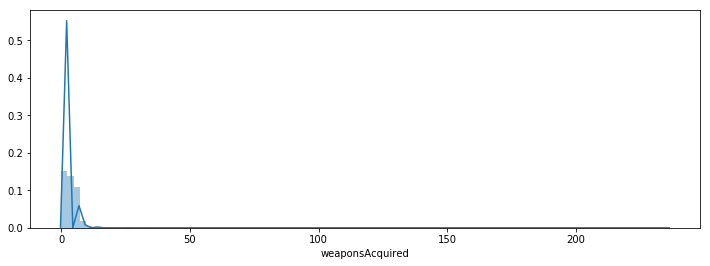

```python
# Plot the distribution of weaponsAcquired
plt.figure(figsize=(12,4))
sns.distplot(train['weaponsAcquired'], bins=100)
plt.show()
```

```python
# Players who acquired more than 80 weapons
display(train[train['weaponsAcquired'] >= 80].shape)
train[train['weaponsAcquired'] >= 80].head()
```

```
(19, 31)
```

|  | Id | groupId | matchId | assists | boosts | damageDealt | DBNOs | headshotKills | heals | killPlace | ... | roadKills | swimDistance | teamKills | vehicleDestroys | walkDistance | weaponsAcquired | winPoints | winPlacePerc | totalDistance | killsWithoutMoving |
| --- | --- | --- | --- | --- | --- | --- | --- | --- | --- | --- | --- | --- | --- | --- | --- | --- | --- | --- | --- | --- | --- |
| 233643 | 7c8c83f5f97d0f | b33b210a52a2f8 | 2e8a0917a71c43 | 0 | 0 | 67.11 | 0 | 0 | 0 | 44 | ... | 0 | 0.00 | 0 | 0 | 1307.0 | 128 | 1577 | 0.7111 | 3187.00 | False |
| 588387 | c58e3e0c2ba678 | 3d3e6100c07ff0 | d04dbb98249f76 | 0 | 1 | 175.30 | 1 | 0 | 2 | 48 | ... | 0 | 0.00 | 0 | 0 | 1687.0 | 80 | 0 | 0.7500 | 1687.00 | False |
| 1437471 | 8f0c855d23e4cd | 679c3316056de8 | fbaf1b3ae1d884 | 1 | 0 | 100.00 | 0 | 0 | 0 | 24 | ... | 0 | 47.21 | 0 | 0 | 2400.0 | 102 | 0 | 0.8929 | 5299.21 | False |
| 1449293 | db54cf45b9ed1c | 898fccaeeb041d | 484b4ae51fe80f | 0 | 0 | 0.00 | 0 | 0 | 0 | 54 | ... | 0 | 0.00 | 0 | 0 | 653.1 | 95 | 0 | 0.5600 | 653.10 | False |
| 1592744 | 634a224c53444e | 75fa7591d1538c | f900de1ec39fa5 | 9 | 0 | 1726.00 | 0 | 3 | 0 | 9 | ... | 0 | 0.00 | 0 | 0 | 980.8 | 94 | 0 | 0.2000 | 2888.80 | False |

5 rows × 31 columns

```python
# Remove outliers
train.drop(train[train['weaponsAcquired'] >= 80].index, inplace=True)
```

## The Healer and booster Players

```python
print("The average person uses {:.1f} heal items, 99% of people use {} or less, while the doctor used {}.".format(train['heals'].mean(), train['heals'].quantile(0.99), train['heals'].max()))
print("The average person uses {:.1f} boost items, 99% of people use {} or less, while the doctor used {}.".format(train['boosts'].mean(), train['boosts'].quantile(0.99), train['boosts'].max()))
```

[output not shown]

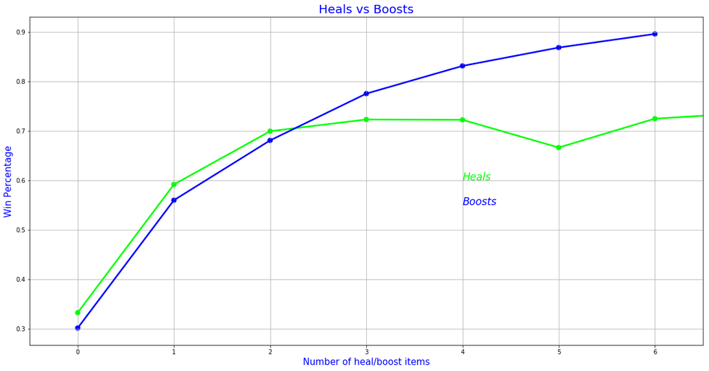

```python
data = train.copy()
data = data[data['heals'] < data['heals'].quantile(0.99)]
data = data[data['boosts'] < data['boosts'].quantile(0.99)]

f,ax1 = plt.subplots(figsize =(20,10))
sns.pointplot(x='heals',y='winPlacePerc',data=data,color='lime',alpha=0.8)
sns.pointplot(x='boosts',y='winPlacePerc',data=data,color='blue',alpha=0.8)
plt.text(4,0.6,'Heals',color='lime',fontsize = 17,style = 'italic')
plt.text(4,0.55,'Boosts',color='blue',fontsize = 17,style = 'italic')
plt.xlabel('Number of heal/boost items',fontsize = 15,color='blue')
plt.ylabel('Win Percentage',fontsize = 15,color='blue')
plt.title('Heals vs Boosts',fontsize = 20,color='blue')
plt.grid()
plt.show()
```

### Here, we can see that as number of heal and boost items increases, there is increase in win percentage, but at a x=5, the heal item used decreases the winning percentage while boost does not.

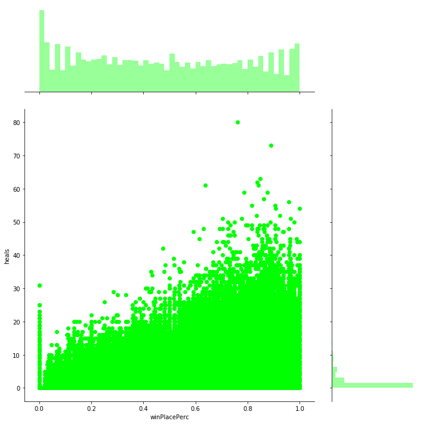

```python
sns.jointplot(x="winPlacePerc", y="heals", data=train, height=10, ratio=3, color="lime")
plt.show()
```

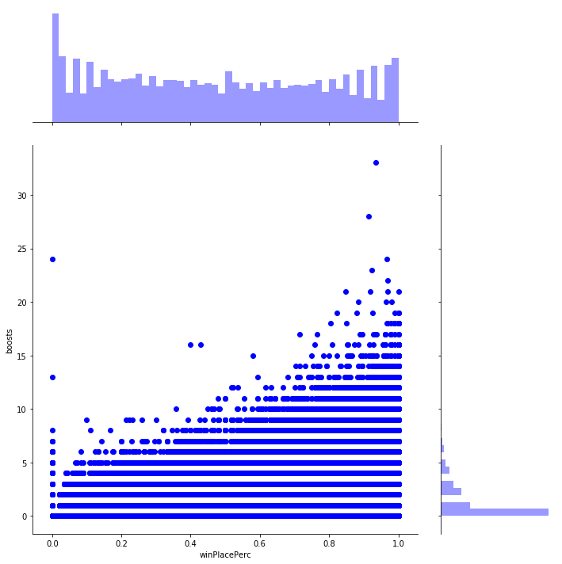

```python
sns.jointplot(x="winPlacePerc", y="boosts", data=train, height=10, ratio=3, color="blue")
plt.show()
```

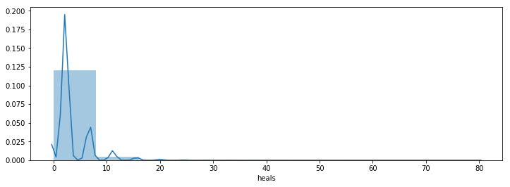

```python
# Distribution of heals
plt.figure(figsize=(12,4))
sns.distplot(train['heals'], bins=10)
plt.show()
```

```python
# 40 or more healing items used
display(train[train['heals'] >= 40].shape)
train[train['heals'] >= 40].head(10)
```

```
(135, 31)
```

|  | Id | groupId | matchId | assists | boosts | damageDealt | DBNOs | headshotKills | heals | killPlace | ... | roadKills | swimDistance | teamKills | vehicleDestroys | walkDistance | weaponsAcquired | winPoints | winPlacePerc | totalDistance | killsWithoutMoving |
| --- | --- | --- | --- | --- | --- | --- | --- | --- | --- | --- | --- | --- | --- | --- | --- | --- | --- | --- | --- | --- | --- |
| 18405 | 63ab976895d860 | 927eeba5614c4f | 69473402649f11 | 0 | 2 | 0.0 | 0 | 0 | 47 | 43 | ... | 0 | 0.000 | 0 | 0 | 1387.0 | 6 | 0 | 0.9368 | 6854.000 | False |
| 54463 | 069ddee7c9d26a | 58ab5a1ce8e06f | 942416b6caf21e | 1 | 4 | 182.0 | 0 | 1 | 43 | 21 | ... | 0 | 292.400 | 0 | 0 | 2791.0 | 7 | 0 | 0.9615 | 3083.400 | False |
| 126439 | c45bd6917146e2 | 81ab9f863957cb | 4335664c6716fa | 0 | 2 | 0.0 | 0 | 0 | 52 | 49 | ... | 0 | 3.443 | 0 | 0 | 1340.0 | 3 | 1543 | 0.8333 | 1343.443 | False |
| 259351 | 86910c38335c2f | 2738398928d28c | 7d2911e944bfaa | 0 | 10 | 0.0 | 0 | 0 | 42 | 45 | ... | 0 | 0.000 | 0 | 0 | 1510.0 | 6 | 0 | 0.8646 | 7444.000 | False |
| 268747 | a007734fbc6ebf | 5bf702dfa1e5d4 | ad6b5669d33a2c | 0 | 5 | 0.0 | 0 | 0 | 48 | 43 | ... | 0 | 0.000 | 0 | 0 | 1968.0 | 9 | 0 | 0.8370 | 5816.000 | False |
| 269098 | a0891dbc2950ea | dde848d90491ba | b4fd3348551b73 | 0 | 2 | 0.0 | 0 | 0 | 42 | 44 | ... | 0 | 0.000 | 0 | 0 | 2439.0 | 2 | 1511 | 0.9259 | 2439.000 | False |
| 284195 | 91a2fb00455eb3 | f639b09774c5b1 | 65b73c71653822 | 0 | 3 | 123.0 | 0 | 0 | 40 | 52 | ... | 0 | 0.000 | 0 | 0 | 2252.0 | 8 | 0 | 0.8276 | 4848.000 | False |
| 300204 | 1f4f2efc86bfcb | 3d668492d1fca9 | d3638466a43d38 | 0 | 6 | 175.0 | 2 | 1 | 47 | 25 | ... | 0 | 0.000 | 0 | 0 | 2928.0 | 3 | 1562 | 0.9355 | 3415.600 | False |
| 349908 | 7725ad71ad2ff7 | 4b2a7cf86d1546 | cfa2775c9ef944 | 3 | 0 | 2348.0 | 0 | 8 | 41 | 9 | ... | 0 | 0.000 | 0 | 0 | 268.8 | 33 | 1500 | 0.8889 | 268.800 | False |
| 375156 | d64866c78ebcb0 | aa0f089ae6430c | 4dbc4ebba33ec6 | 0 | 7 | 278.5 | 3 | 1 | 44 | 3 | ... | 0 | 0.000 | 0 | 0 | 2489.0 | 6 | 1517 | 0.9630 | 4927.000 | False |

10 rows × 31 columns

```python
# Remove outliers
train.drop(train[train['heals'] >= 40].index, inplace=True)
```

```python
# Remaining players in the training set
train.shape
```

```
(4444776, 31)
```

## Solos, Duos, Squads

```python
solos = train[train['numGroups']>50]
duos = train[(train['numGroups']>25) & (train['numGroups']<=50)]
squads = train[train['numGroups']<=25]
print("There are {} ({:.2f}%) solo games, {} ({:.2f}%) duo games and {} ({:.2f}%) squad games.".format(len(solos), 100*len(solos)/len(train), len(duos), 100*len(duos)/len(train), len(squads), 100*len(squads)/len(train),))
```

[output not shown]

[figure not shown]

```python
f,ax1 = plt.subplots(figsize =(20,10))
sns.pointplot(x='kills',y='winPlacePerc',data=solos,color='black',alpha=0.8)
sns.pointplot(x='kills',y='winPlacePerc',data=duos,color='#CC0000',alpha=0.8)
sns.pointplot(x='kills',y='winPlacePerc',data=squads,color='#3399FF',alpha=0.8)
plt.text(37,0.6,'Solos',color='black',fontsize = 17,style = 'italic')
plt.text(37,0.55,'Duos',color='#CC0000',fontsize = 17,style = 'italic')
plt.text(37,0.5,'Squads',color='#3399FF',fontsize = 17,style = 'italic')
plt.xlabel('Number of kills',fontsize = 15,color='blue')
plt.ylabel('Win Percentage',fontsize = 15,color='blue')
plt.title('Solo vs Duo vs Squad Kills',fontsize = 20,color='blue')
plt.grid()
plt.show()
```

### After number of kills=7, the win percentage of squads is not depending on no. of kills, whereas as no of kills increases, win percentage increases.

## Now, we will be plotting features which are available only for duos and squads: DBNOs,revives and assists.

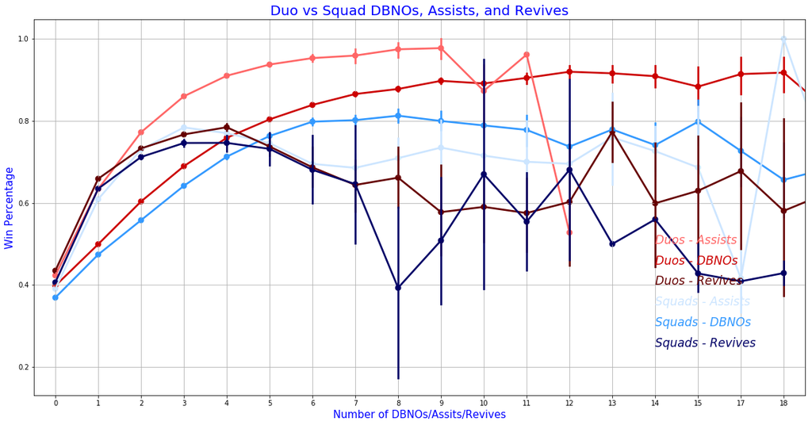

```python
f,ax1 = plt.subplots(figsize =(20,10))
sns.pointplot(x='DBNOs',y='winPlacePerc',data=duos,color='#CC0000',alpha=0.8)
sns.pointplot(x='DBNOs',y='winPlacePerc',data=squads,color='#3399FF',alpha=0.8)
sns.pointplot(x='assists',y='winPlacePerc',data=duos,color='#FF6666',alpha=0.8)
sns.pointplot(x='assists',y='winPlacePerc',data=squads,color='#CCE5FF',alpha=0.8)
sns.pointplot(x='revives',y='winPlacePerc',data=duos,color='#660000',alpha=0.8)
sns.pointplot(x='revives',y='winPlacePerc',data=squads,color='#000066',alpha=0.8)
plt.text(14,0.5,'Duos - Assists',color='#FF6666',fontsize = 17,style = 'italic')
plt.text(14,0.45,'Duos - DBNOs',color='#CC0000',fontsize = 17,style = 'italic')
plt.text(14,0.4,'Duos - Revives',color='#660000',fontsize = 17,style = 'italic')
plt.text(14,0.35,'Squads - Assists',color='#CCE5FF',fontsize = 17,style = 'italic')
plt.text(14,0.3,'Squads - DBNOs',color='#3399FF',fontsize = 17,style = 'italic')
plt.text(14,0.25,'Squads - Revives',color='#000066',fontsize = 17,style = 'italic')
plt.xlabel('Number of DBNOs/Assits/Revives',fontsize = 15,color='blue')
plt.ylabel('Win Percentage',fontsize = 15,color='blue')
plt.title('Duo vs Squad DBNOs, Assists, and Revives',fontsize = 20,color='blue')
plt.grid()
plt.show()
```

## Pearson correlation between features.

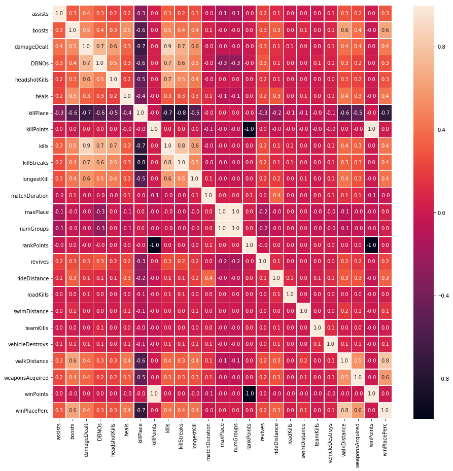

```python
f,ax = plt.subplots(figsize=(15, 15))
sns.heatmap(train.corr(), annot=True, linewidths=.5, fmt= '.1f',ax=ax)
plt.show()
```

### In terms of the target variable (winPlacePerc), there are a few variables high medium to high correlation. The highest positive correlation is walkDistance and the highest negative the killPlace.

```python
# One hot encode matchType
train = pd.get_dummies(train, columns=['matchType'])

# Take a look at the encoding
matchType_encoding = train.filter(regex='matchType')
matchType_encoding.head()
```

|  | matchType_crashfpp | matchType_crashtpp | matchType_duo | matchType_duo-fpp | matchType_flarefpp | matchType_flaretpp | matchType_normal-duo | matchType_normal-duo-fpp | matchType_normal-solo | matchType_normal-solo-fpp | matchType_normal-squad | matchType_normal-squad-fpp | matchType_solo | matchType_solo-fpp | matchType_squad | matchType_squad-fpp |
| --- | --- | --- | --- | --- | --- | --- | --- | --- | --- | --- | --- | --- | --- | --- | --- | --- |
| 0 | 0 | 0 | 0 | 0 | 0 | 0 | 0 | 0 | 0 | 0 | 0 | 0 | 0 | 0 | 0 | 1 |
| 1 | 0 | 0 | 0 | 0 | 0 | 0 | 0 | 0 | 0 | 0 | 0 | 0 | 0 | 0 | 0 | 1 |
| 2 | 0 | 0 | 1 | 0 | 0 | 0 | 0 | 0 | 0 | 0 | 0 | 0 | 0 | 0 | 0 | 0 |
| 3 | 0 | 0 | 0 | 0 | 0 | 0 | 0 | 0 | 0 | 0 | 0 | 0 | 0 | 0 | 0 | 1 |
| 4 | 0 | 0 | 0 | 0 | 0 | 0 | 0 | 0 | 0 | 0 | 0 | 0 | 0 | 1 | 0 | 0 |

```python
# Turn groupId and match Id into categorical types
train['groupId'] = train['groupId'].astype('category')
train['matchId'] = train['matchId'].astype('category')

# Get category coding for groupId and matchID
train['groupId_cat'] = train['groupId'].cat.codes
train['matchId_cat'] = train['matchId'].cat.codes

# Get rid of old columns
train.drop(columns=['groupId', 'matchId'], inplace=True)

# Lets take a look at our newly created features
train[['groupId_cat', 'matchId_cat']].head()
```

|  | groupId_cat | matchId_cat |
| --- | --- | --- |
| 0 | 613591 | 30085 |
| 1 | 827582 | 32751 |
| 2 | 843273 | 3143 |
| 3 | 1340072 | 45260 |
| 4 | 1757338 | 20531 |

```python
# Drop Id column, because it probably won't be useful for our Machine Learning algorithm,
# because the test set contains different Id's
train.drop(columns = ['Id'], inplace=True)
```

```python
sample = 500000
df_sample = train.sample(sample)
# Split sample into training data and target variable
df = df_sample.drop(columns = ['winPlacePerc']) #all columns except target
y = df_sample['winPlacePerc'] # Only target variable

x_train, x_test, y_train, y_test=train_test_split(df,y,test_size=0.3, random_state=0)
print(x_train.shape)
print(x_test.shape)
print(y_train.shape)
print(y_test.shape)
```

```
(350000, 44)
(150000, 44)
(350000,)
(150000,)
```

```python
# Function for splitting training and validation data
def split_vals(a, n : int):
    return a[:n].copy(), a[n:].copy()
val_perc = 0.20 # % to use for validation set
n_valid = int(val_perc * 350000)
n_trn = len(x_train)-n_valid
# Split data
raw_train, raw_valid = split_vals(df_sample, n_trn)
X_train, X_valid = split_vals(x_train, n_trn)
y_train, y_valid = split_vals(y_train, n_trn)

# Check dimensions of samples
print('Sample train shape: ', X_train.shape,
      'Sample target shape: ', y_train.shape,
      'Sample validation shape: ', X_valid.shape)
```

```
Sample train shape:  (280000, 44) Sample target shape:  (280000,) Sample validation shape:  (70000, 44)
```

```python
base_learners = [300]
depth = [50]
param_grid = {'n_estimators': base_learners,'max_depth': depth}
RFC = RandomForestRegressor(max_features='sqrt')
model = GridSearchCV(RFC, param_grid, cv=3 , n_jobs = -1,pre_dispatch=2)
model.fit(X_train, y_train)
print("Model with best parameters :\n",model.best_estimator_)
# Optimal value of number of base learners
optimal_learners = model.best_estimator_.n_estimators
print("The optimal number of base learners is : ",optimal_learners)

optimal_depth=model.best_estimator_.max_depth
print("The optimal number of depth is : ",optimal_depth)
```

```
Model with best parameters :
 RandomForestRegressor(bootstrap=True, criterion='mse', max_depth=50,
           max_features='sqrt', max_leaf_nodes=None,
           min_impurity_decrease=0.0, min_impurity_split=None,
           min_samples_leaf=1, min_samples_split=2,
           min_weight_fraction_leaf=0.0, n_estimators=300, n_jobs=1,
           oob_score=False, random_state=None, verbose=0, warm_start=False)
The optimal number of base learners is :  300
The optimal number of depth is :  50
```

```python
y_pred=model.predict(x_test)
print("Misclassified samples: %d"%(y_test!=y_pred).sum())
mse = mean_squared_error(y_test,y_pred)
print("RMSE :", np.sqrt(mse))
mae=mean_absolute_error(y_test,y_pred)
print("MAE :", mae)
```

```
Misclassified samples: 149983
RMSE : 0.08935445877043544
MAE : 0.06389176893623487
```

```python
# Metric used for the PUBG competition (Mean Absolute Error (MAE))
# Function to print the MAE (Mean Absolute Error) score
# This is the metric used by Kaggle in this competition
def print_score(m : RandomForestRegressor):
    res = ['mae train: ', mean_absolute_error(m.predict(X_train), y_train),
           'mae val: ', mean_absolute_error(m.predict(X_valid), y_valid)]
    if hasattr(m, 'oob_score_'): res.append(m.oob_score_)
    print(res)
```